# sns_assignment - submission version

```python
import pandas as pd
import numpy as np
import matplotlib.pyplot as plt
# for the scatter plot render
import seaborn as sns


URL = './NASDAQ_100_Data_From_2010.csv/NASDAQ_100_Data_From_2010.csv'
stock_data_raw = pd.read_csv(URL)
stock_data_raw.head()
```

|  | Date\tOpen\tHigh\tLow\tClose\tAdj Close\tVolume\tName |
| --- | --- |
| 0 | 2010-01-04\t7.622499942779541\t7.6607141494750... |
| 1 | 2010-01-05\t7.664286136627197\t7.6996431350708... |
| 2 | 2010-01-06\t7.656428813934326\t7.6867861747741... |
| 3 | 2010-01-07\t7.5625\t7.5714287757873535\t7.4660... |
| 4 | 2010-01-08\t7.510714054107666\t7.5714287757873... |

```python
# Because the raw data is not splitted by , need to handle the dataset first
def generate_dataset():
    URL = './NASDAQ_100_Data_From_2010.csv/NASDAQ_100_Data_From_2010.csv'
    # URL = './google stock/GOOG.csv'
    NASDAQ_stock_data = pd.read_csv(URL)
    NASDAQ_stock_data.head()
    # df_All_stock = pd.DataFrame(columns="Date\tOpen\tHigh\tLow\tClose\tAdj Close\tVolume\tName".split('\t'))

    raw_list = []
    # df_All_stock.iloc[:0] = ['2010-01-05', '7.664286136627197', '7.699643135070801', '7.6160712242126465', '7.656428813934326', '6.573935031890869', '601904800', 'AAPL']
    for i in range(0, len(NASDAQ_stock_data.index)):
        row_str_list = NASDAQ_stock_data.iloc[i,0].split('\t')
        raw_list.append(row_str_list)
    df_All_stock = pd.DataFrame(raw_list, columns="Date\tOpen\tHigh\tLow\tClose\tAdj Close\tVolume\tName".split('\t'))

    df_All_stock.head()
    print("======df_All_stock.shape == ", df_All_stock.shape)
    df_All_stock['Date'] = df_All_stock['Date'].astype("datetime64")
    df_All_stock['Open'] = df_All_stock['Open'].astype("float")
    df_All_stock['High'] = df_All_stock['High'].astype("float")
    df_All_stock['Low'] = df_All_stock['Low'].astype("float")
    df_All_stock['Close'] = df_All_stock['Close'].astype("float")
    df_All_stock['Adj Close'] = df_All_stock['Adj Close'].astype("float")
    df_All_stock['Volume'] = df_All_stock['Volume'].astype("int")
    df_All_stock['Name'] = df_All_stock['Name'].astype("string")
    df_All_stock.dtypes

    df_All_stock.to_csv('NASDAQ_stock_data_df.csv')
# generate_dataset()
```

```python
URL = './NASDAQ_stock_data_df.csv'
stock_data = pd.read_csv(URL)
# stock_data.set_index("Date", inplace=True)
stock_data.drop(["Unnamed: 0"], axis=1, inplace=True)
print("stock_data.shape>>>", stock_data.shape)
print("stock_data.columns>>>", stock_data.columns)
print(stock_data.tail(1))
stock_data.head()
```

```
stock_data.shape>>> (271680, 8)
stock_data.columns>>> Index(['Date', 'Open', 'High', 'Low', 'Close', 'Adj Close', 'Volume', 'Name'], dtype='object')
              Date        Open     High         Low  Close  Adj Close  \
271679  2021-09-10  296.910004  306.263  296.809998  301.5      301.5

         Volume Name
271679  6089600   ZM
```

|  | Date | Open | High | Low | Close | Adj Close | Volume | Name |
| --- | --- | --- | --- | --- | --- | --- | --- | --- |
| 0 | 2010-01-04 | 7.622500 | 7.660714 | 7.585000 | 7.643214 | 6.562591 | 493729600 | AAPL |
| 1 | 2010-01-05 | 7.664286 | 7.699643 | 7.616071 | 7.656429 | 6.573935 | 601904800 | AAPL |
| 2 | 2010-01-06 | 7.656429 | 7.686786 | 7.526786 | 7.534643 | 6.469369 | 552160000 | AAPL |
| 3 | 2010-01-07 | 7.562500 | 7.571429 | 7.466071 | 7.520714 | 6.457407 | 477131200 | AAPL |
| 4 | 2010-01-08 | 7.510714 | 7.571429 | 7.466429 | 7.570714 | 6.500339 | 447610800 | AAPL |

# Explotary Data Anaylsis

The first step is to do some EDA to see different charactertics of the data set.

```python
"""
===1. Choose the Companies Symbol

"""
print(">>> RAW data shape", stock_data.shape)
stock_data.info()
# Unique data obervation of each column
print(stock_data.nunique())
# See the symbols list
stock_data_symbols = stock_data[["Name"]]
symbol_list = stock_data_symbols["Name"].unique()
print("====== Companies Symbol List ======\n")
print(symbol_list)
```

```
>>> RAW data shape (271680, 8)
<class 'pandas.core.frame.DataFrame'>
RangeIndex: 271680 entries, 0 to 271679
Data columns (total 8 columns):
 #   Column     Non-Null Count   Dtype
---  ------     --------------   -----
 0   Date       271680 non-null  object
 1   Open       271680 non-null  float64
 2   High       271680 non-null  float64
 3   Low        271680 non-null  float64
 4   Close      271680 non-null  float64
 5   Adj Close  271680 non-null  float64
 6   Volume     271680 non-null  int64
 7   Name       271680 non-null  object
dtypes: float64(5), int64(1), object(2)
memory usage: 16.6+ MB
Date           2943
Open          68178
High          69492
Low           68973
Close         70096
Adj Close    188419
Volume       124591
Name            102
dtype: int64
====== Companies Symbol List ======

['AAPL' 'ADBE' 'ADI' 'ADP' 'ADSK' 'AEP' 'ALGN' 'AMAT' 'AMD' 'AMGN' 'AMZN'
 'ANSS' 'ASML' 'ATVI' 'AVGO' 'BIDU' 'BIIB' 'BKNG' 'CDNS' 'CDW' 'CERN'
 'CHKP' 'CHTR' 'CMCSA' 'COST' 'CPRT' 'CRWD' 'CSCO' 'CSX' 'CTAS' 'CTSH'
 'DLTR' 'DOCU' 'DXCM' 'EA' 'EBAY' 'EXC' 'FAST' 'FB' 'FISV' 'FOX' 'FOXA'
 'GILD' 'GOOG' 'GOOGL' 'HON' 'IDXX' 'ILMN' 'INCY' 'INTC' 'INTU' 'ISRG'
 'JD' 'KDP' 'KHC' 'KLAC' 'LRCX' 'LULU' 'MAR' 'MCHP' 'MDLZ' 'MELI' 'MNST'
 'MRNA' 'MRVL' 'MSFT' 'MTCH' 'MU' 'NFLX' 'NTES' 'NVDA' 'NXPI' 'OKTA'
 'ORLY' 'PAYX' 'PCAR' 'PDD' 'PEP' 'PTON' 'PYPL' 'QCOM' 'REGN' 'ROST'
 'SBUX' 'SGEN' 'SIRI' 'SNPS' 'SPLK' 'SWKS' 'TCOM' 'TEAM' 'TMUS' 'TSLA'
 'TXN' 'VRSK' 'VRSN' 'VRTX' 'WBA' 'WDAY' 'XEL' 'XLNX' 'ZM']
```

```python
# Create the interested symbol list
stock_dict = {
    'AAPL': 'Apple Inc.',
    'AMD': 'Advanced Micro Devices, Inc.',
    'AMZN': 'Amazon.com, Inc.',
    'BIDU': 'Baidu, Inc.ADS',
    'CSCO': 'Cisco Systems, Inc.(DE)',
    'FB': 'Facebook, Inc.',
    'GOOG': 'Alphabet Inc.Class C Capital Stock',
    'GOOGL': 'Alphabet Inc.',
    'JD': 'JD.com, Inc.',
    'NFLX': 'Netflix, Inc.',
    'NVDA': 'NVIDIA Corporation',
    'PYPL': 'PayPal Holdings, Inc.',
    'QCOM': 'QUALCOMM Incorporated',
    'TSLA': 'Tesla, Inc.',
    'ZM': 'Zoom Video Communications, Inc.'
}

stock_list = ['AAPL','AMZN','GOOG','FB']

# Create the interested symbol list
stock_dict = {
    'AAPL': 'Apple Inc.',
    'AMD': 'Advanced Micro Devices, Inc.',
    'AMZN': 'Amazon.com, Inc.',
    'BIDU': 'Baidu, Inc.ADS',
    'CSCO': 'Cisco Systems, Inc.(DE)',
    'FB': 'Facebook, Inc.',
    'GOOG': 'Alphabet Inc.Class C Capital Stock',
    'GOOGL': 'Alphabet Inc.',
}

stock_list = ['AAPL','AMZN','GOOG','FB']


def stock_show(stock_name):
    # print(stock_name, end=" ")
    # print(" stock is %s" %stock_dict[stock_name])
    if stock_name in list(stock_dict.keys()):
        print("Asking stock is %s" %stock_dict[stock_name])
        ans = "The company full name: "+ stock_dict[stock_name]
        return ans
    return ""

ans = stock_show("FBI")
print(ans)
```

## Apple Company Stock EDA

```python
"""
google_stock_data = google_stock_data[["date", "open", "close"]]
google_stock_data["date"] = pd.to_datetime(google_stock_data["date"].apply(lambda x: x.split()[0]))
google_stock_data.set_index('date', inplace=True)
google_stock_data.head()
"""
# Choose the data feature we want to predict ==== 'date', 'open', 'close'
def generate_company_set(com_symbol):
    row_list = []
    # df_com = pd.DataFrame(columns=stock_data.columns)
    for i in range(0, len(stock_data.index)):
        if stock_data.loc[i,"Name"] == com_symbol:
            tmp_df = stock_data.loc[i,:]
            row_list.append(tmp_df)

    df_com = pd.DataFrame(row_list, columns=stock_data.columns)
    return df_com

apple = generate_company_set("AAPL")
# google = generate_company_set("GOOG")
apple["Date"] = pd.to_datetime(apple["Date"].apply(lambda x: x.split()[0]))
apple.set_index('Date', inplace=True)
print("======Data Shape======")
print(apple.shape)
print("======Data Dtypes======")
print(apple.dtypes)
apple.head()
```

```
======Data Shape======
(2943, 7)
======Data Dtypes======
Open         float64
High         float64
Low          float64
Close        float64
Adj Close    float64
Volume         int64
Name          object
dtype: object
```

| Date | Open | High | Low | Close | Adj Close | Volume | Name |
| --- | --- | --- | --- | --- | --- | --- | --- |
| 2010-01-04 | 7.622500 | 7.660714 | 7.585000 | 7.643214 | 6.562591 | 493729600 | AAPL |
| 2010-01-05 | 7.664286 | 7.699643 | 7.616071 | 7.656429 | 6.573935 | 601904800 | AAPL |
| 2010-01-06 | 7.656429 | 7.686786 | 7.526786 | 7.534643 | 6.469369 | 552160000 | AAPL |
| 2010-01-07 | 7.562500 | 7.571429 | 7.466071 | 7.520714 | 6.457407 | 477131200 | AAPL |
| 2010-01-08 | 7.510714 | 7.571429 | 7.466429 | 7.570714 | 6.500339 | 447610800 | AAPL |

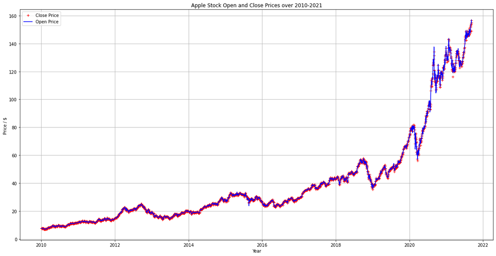

```python
"""
fg, ax =plt.subplots(1,2,figsize=(20,7))
ax[0].plot(google_stock_data['open'],label='Open',color='green')
ax[0].set_xlabel('Date',size=15)
ax[0].set_ylabel('Price',size=15)
ax[0].legend()

ax[1].plot(google_stock_data['close'],label='Close',color='red')
ax[1].set_xlabel('Date',size=15)
ax[1].set_ylabel('Price',size=15)
ax[1].legend()

fg.show()
"""

plt.figure(figsize=(20,10))
plt.plot(apple['Close'], '+r',label='Close Price')
plt.plot(apple['Open'], '-b',label='Open Price')
plt.legend()
plt.grid()
plt.xlabel("Year")
plt.ylabel("Price / $ ")
plt.title("Apple Stock Open and Close Prices over 2010-2021")
plt.show()
```

```
'\n1. For Stock data, the most valuable data is the closing price. \nFrom the Scatter plot, we can see there are many features are linear to close price and we may use them to predict furture close price.\n'
```

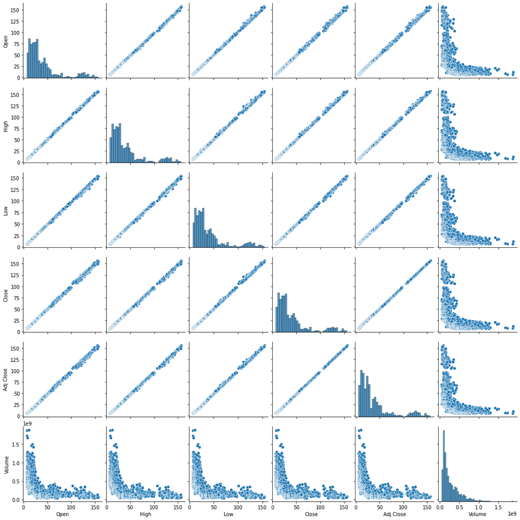

```python
# 3. Draw the scatter plot of different features and see the relationship among them
# print(apple.head())
plt.figure(figsize=(10,10))
sns.pairplot(apple)

#=== 4. Draw the scatter plot for 4 companies to see the correlation among them


# 5. Decide what to predict
"""
1. For Stock data, the most valuable data is the closing price.
From the Scatter plot, we can see there are many features are linear to close price and we may use them to predict furture close price.
"""
```

```python
four_companies_closing = pd.DataFrame(index={"Date": range(0, 2944)})
# stock_list = ['GOOG','AMZN']

for company in stock_list:
    tmp = generate_company_set(company)
    # print(tmp.shape)
    tmp[company] = tmp.loc[:, "Close"]
    tmp = tmp[[company]]
    tmp.reset_index(drop=True)
    print(tmp.head())
    # four_companies_closing.loc[:, company] = tmp["Close"]
    four_companies_closing = four_companies_closing.join(tmp)
    # four_companies_closing = pd.concat([four_companies_closing, tmp[["Close"]]], axis=1, ignore_index=True)
    # four_companies_closing["Date"] = stock_data["Date"]
four_companies_closing.tail()
```

```
       AAPL
0  7.643214
1  7.656429
2  7.534643
3  7.520714
4  7.570714
             AMZN
29430  133.899994
29431  134.690002
29432  132.250000
29433  130.000000
29434  133.520004
              GOOG
115976  312.204773
115977  310.829926
115978  302.994293
115979  295.940735
115980  299.885956
               FB
106483  38.230000
106484  34.029999
106485  31.000000
106486  32.000000
106487  33.029999
```

|  | AAPL | AMZN | GOOG | FB |
| --- | --- | --- | --- | --- |
| Date | NaN | NaN | NaN | NaN |

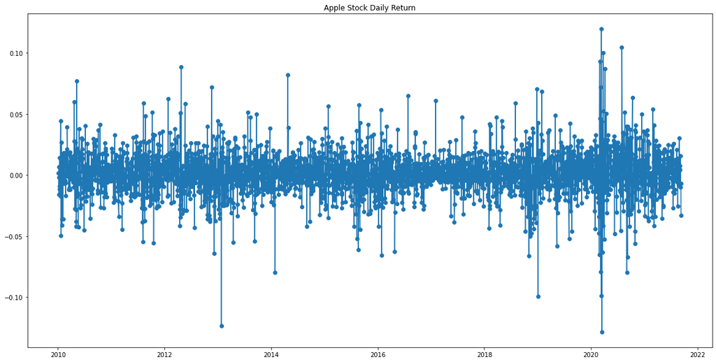

```python
apple['Daily Return'] = apple['Adj Close'].pct_change()
plt.figure(figsize=(20,10))
plt.plot(apple['Daily Return'], marker='o',label='Daily Return')
plt.title("Apple Stock Daily Return")
plt.show()
```

```python
# Check to missing value and handle it
apple.isnull().sum()
```

```
Open            0
High            0
Low             0
Close           0
Adj Close       0
Volume          0
Name            0
Daily Return    1
dtype: int64
```

## Choose Prediction

Choose the 'close' price to predict.

# Data Pre-processing

## Dataset Desgin

From above EDA analysis, we choose the "Close" price of different companies to predict. For the training dataset, we need to do as follow:

1. Change the dataset into numeric because DNN only takes numeric values as input.
   - Since the data already in float, no need to vectorize such as "one-hot" coding.
2. Generate the data-set for train and test
   - In python, there are many ways to generate the dataset, one is put all the data into one dataframe. The other is put the data into a Generator.

## Define some general use function

```
# Collect Data Function using the company Symbol
def generate_company_set_date(com_symbol, year=2010, month=1, day=1):
# Split dataset into train and test using the percentage
def generate_MinMAX_dataset(df, train_split_per):

def split_sequence(sequence_x, sequence_y, n_steps_in, n_steps_out):
# Give stock and related cols. Plot different plt
### Default is plot the Close Price
def plot_df_val(df, column, stock, title=' Price History For ', ylabel=" Price USD($) for "):
def draw_train_from_history(his):


# Evalution Metrics
def calculate_rmse(y_true, y_pred):
def calculate_mape(y_true, y_pred):
```

```python
# 1. Collect Data Function using the company Symbol
import datetime
from sklearn.preprocessing import MinMaxScaler, StandardScaler
from sklearn.model_selection import train_test_split

def generate_company_set_date(com_symbol, year=2010, month=1, day=1):
    row_list = []
    for i in range(0, len(stock_data.index)):
        if stock_data.loc[i,"Name"] == com_symbol:
            tmp_df = stock_data.loc[i,:]
            row_list.append(tmp_df)

    df_com = pd.DataFrame(row_list, columns=stock_data.columns)
    # df_com["Date"] = df_com["Date"].astype("datetime64")
    df_com["Date"] = pd.to_datetime(df_com["Date"])
    # print(df_com.dtypes)
    # Filter for specific date
    df_com = df_com[df_com["Date"] > pd.Timestamp(datetime.date(year, month, day))]
    # df_com["Date"] = pd.to_datetime(df_com["Date"].apply(lambda x: x.split()[0]))
    # df_com.set_index('Date', inplace=True)
    # df_com.sort_index(axis=0)
    return df_com

"""
=========== For Draw the image ===========

"""
# For Regression Problem
def draw_train_from_history(his):
    plt.figure(figsize=(10,10))
    # fig, (ax1, ax2) = plt.subplots(2,1)
    plt.plot(his.history['loss'],label='Train_Loss')
    plt.plot(his.history['val_loss'],label='Validation_Loss')
    plt.legend()
    # ax2.plot(history.history['mean_squared_error'],label='Train_ACC')
    # ax2.plot(history.history['val_mean_squared_error'],label='Validation_ACC')
    # ax2.legend()


def plot_df_val(df, column, stock, title=' Price History For ', ylabel="USD($) for "):
    plt.clf()
    plt.figure(figsize=(16,6))
    plt.title(str(column)+title+stock)
    plt.plot(df[column], label="column")
    plt.xlabel('Date', fontsize=18)
    plt.ylabel(ylabel +stock, fontsize=18)
    plt.grid()
    plt.legend(column)
    plt.show()


"""
=========== Calculate the metrics RMSE and MAPE ===========
"""
def calculate_rmse(y_true, y_pred):
    """
    Calculate the Root Mean Squared Error (RMSE)
    """
    rmse = np.sqrt(np.mean((y_true-y_pred)**2))
    return rmse

def calculate_mape(y_true, y_pred):
    """
    Calculate the Mean Absolute Percentage Error (MAPE) %
    """
    y_pred, y_true = np.array(y_pred), np.array(y_true)
    y_pred = np.nan_to_num(y_pred)
    y_true = np.nan_to_num(y_true)
    mape = np.mean(np.abs((y_true-y_pred) / y_true))*100
    return mape



"""
============ For DataSet Prepration ============
"""
# Use for Scale
# scaler = MinMaxScaler(feature_range=(0,1))
scaler = StandardScaler()


# StandardScaler
def std_data(x):
    scaler_data = scaler.fit_transform(x)
    return scaler_data


# split data into samples
# n_steps_in= sample input_train
# n_steps_out= sample output_train
def split_sequence(sequence_x, sequence_y, n_steps_in, n_steps_out):
    X = []
    y = []
    for i in range(len(sequence_x)):
        # find the end of this pattern
        end_ix = i + n_steps_in
        out_end_ix = end_ix + n_steps_out
        # check if we are beyond the sequence
        if out_end_ix > len(sequence_x):
            break
        # gather input and output parts of the pattern
        seq_x, seq_y = sequence_x[i:end_ix], sequence_x[end_ix:out_end_ix,0]
        X.append(seq_x)
        y.append(seq_y)
    print(">>>>>>>>>>In split_sequence\\n",np.array(X).shape)
    return np.array(X), np.array(y)


def split_dataset_test_train(X, y, split_factor):
    train_data_len = int(np.ceil( len(X[:,0]) * split_factor))
    # Split the data into train and test
    X_train = X[0:train_data_len]
    X_test = X[train_data_len:]
    y_train = y[0:train_data_len]
    y_test = y[train_data_len:]

    return X_train, X_test, y_train, y_test

def filter_x_y(df):
    predict_dataset = df.filter(['Date', 'Close', 'Open', 'Low', 'High', 'Adj Close'])
    X = predict_dataset.filter(['Close', 'Open', 'Low', 'High', 'Adj Close'])
    # X = predict_dataset.filter(['Close'])
    y = predict_dataset.filter(['Close'])

    return X, y



def generate_from_data(X, y, n_steps_in, n_steps_out):
    # Set the time step for both train data set and test
    # print(X)
    # X_train, Y_train = split_sequence(X, y, n_steps_in, n_steps_out)

    X_, Y_ = split_sequence(X, y, n_steps_in, n_steps_out)
    n_feature = 5
    # reshape from [samples, timesteps] into [samples, timesteps, features]
    X_ = X_.reshape(X_.shape[0], X_.shape[1], n_feature)
    # X_test = X_test.reshape(X_test.shape[0], X_test.shape[1], n_feature)
    print("====Generate X_ shape====", X_.shape)    #  (2348, 7, 5)
    print("====Generate Y_ shape====", Y_.shape)    # (2348, 1, 5)
    # print("====Generate X_test shape====", X_test.shape)    # (581, 7, 5)
    # print("====Generate Y_test shape====", Y_test.shape)    # (581, 1, 5)
    return X_, Y_

"""
====== Run main function to get the normalized data for train
1. get the raw datafram
2. Scale the data
3. Split into X_train adn X_test
"""
apple = generate_company_set_date("AAPL", 2010,1,1)
# Get the data for X, y
X, y= filter_x_y(apple)

# Use for Scale
scaler = MinMaxScaler()
X = scaler.fit_transform(np.array(X))

X_, y_ = generate_from_data(X, np.array(y), 50, 1)

# X_train, X_test, y_train, y_test = train_test_split(X, y, test_size = 0.2, shuffle=False)
X_train, X_test, y_train, y_test = split_dataset_test_train(X_, y_, 0.8)

train_size = len(X_train)
print(y_test[10])
```

```
>>>>>>>>>>In split_sequence\n (2893, 50, 5)
====Generate X_ shape==== (2893, 50, 5)
====Generate Y_ shape==== (2893, 1)
[0.27823715]
```

```python
X_train[len(X_train)-1,0,0]
```

```
0.26477197788475465
```